# RPC-PI Experiment - Efficiency Trade-off Analysis

2026-07-04

# 1 Objective

This R Markdown analyzes the **cost-benefit trade-off** of the defense scenarios.

It joins:

```
quality metrics from inference results
training cost from training logs
inference cost from inference logs
optional total pipeline cost from pipeline logs
```

The main questions are:

```
Which defense gives the best robustness gain for its training cost?
Which defense reduces ASV the most per training hour?
Which defense is most efficient at inference time?
Which scenarios are Pareto-efficient when considering quality and cost?
```

This report is designed to follow:

```
14_training_time_analysis.Rmd
15_inference_time_analysis.Rmd
16_pipeline_runtime_analysis.Rmd
```

but it recomputes the core metrics directly from source files when possible.

# 2 Interpretation

Higher is better for:

```
clean_accuracy
robust_accuracy
robust_gain_vs_c0
asv_reduction_vs_c0
robust_retention
benefit_per_cost
```

Lower is better for:

```
ASV
inference_seconds_per_example
training_hours
pipeline_hours
invalid_output_rate
```

C0 is the base reference. C1 has no training cost because it is format-only. C2/C3/C4 have training costs.

# 3 Paths

```r
OUT_TABLE_DIR <- here::here("tables", "efficiency_tradeoff_analysis")
OUT_FIG_DIR <- here::here("figures", "efficiency_tradeoff_analysis")

fs::dir_create(OUT_TABLE_DIR)
fs::dir_create(OUT_FIG_DIR)

# Try to extract logs.zip automatically if needed.
if (!dir.exists(here::here("data", "logs")) && file.exists(here::here("logs.zip"))) {
  dir.create(here::here("data"), showWarnings = FALSE)
  unzip(here::here("logs.zip"), exdir = here::here("data"))
}

if (!dir.exists(here::here("data", "logs")) && file.exists(here::here("data", "logs.zip"))) {
  dir.create(here::here("data"), showWarnings = FALSE)
  unzip(here::here("data", "logs.zip"), exdir = here::here("data"))
}

candidate_logs_dirs <- c(
  here::here("data", "logs"),
  here::here("logs")
)

LOGS_DIR <- candidate_logs_dirs[dir.exists(candidate_logs_dirs)][1]

if (is.na(LOGS_DIR)) {
  stop(
    "Could not find logs directory. Expected one of:\n",
    paste(candidate_logs_dirs, collapse = "\n"),
    "\nOr place logs.zip in the project root or data/."
  )
}

DESC_INFERENCE_PATH <- here::here("tables", "descriptive", "01_inference_compact.csv")

if (!file.exists(DESC_INFERENCE_PATH)) {
  stop(
    "Could not find tables/descriptive/01_inference_compact.csv. ",
    "Run 01_descriptive_metrics.Rmd first."
  )
}

TRAINING_SUMMARY_PATH <- file.path(LOGS_DIR, "training", "04_run_training_summary.json")
INFERENCE_RUNS_DIR <- file.path(LOGS_DIR, "inference", "runs")
PIPELINE_COST_PATH <- here::here("tables", "pipeline_runtime_analysis", "10_scenario_total_pipeline_cost.csv")
```

# 4 Helper functions

```r
`%||%` <- function(x, y) {
  if (is.null(x) || length(x) == 0) y else x
}

scenario_order <- c(
  "c0_base",
  "c1_struq_format_only",
  "c2_struq_sft",
  "c3_secalign_dpo",
  "c4_ih_sft"
)

scenario_labels <- tibble(
  scenario_id = scenario_order,
  scenario_short = c("C0", "C1", "C2", "C3", "C4"),
  scenario_label = c(
    "C0 - Base model",
    "C1 - StruQ format-only",
    "C2 - StruQ-like SFT",
    "C3 - SecAlign-like DPO",
    "C4 - Instruction-Hierarchy-like SFT"
  )
)

scenario_palette <- c(
  C0 = "#7F7F7F",
  C1 = "#D55E00",
  C2 = "#0072B2",
  C3 = "#CC79A7",
  C4 = "#009E73"
)

sort_scenarios <- function(df) {
  df |>
    mutate(
      scenario_id = factor(as.character(scenario_id), levels = scenario_order),
      scenario_short = factor(as.character(scenario_short), levels = c("C0", "C1", "C2", "C3", "C4"))
    ) |>
    arrange(scenario_id)
}

add_scenario_info <- function(df) {
  if (!("scenario_id" %in% names(df))) {
    df$scenario_id <- NA_character_
  }

  out <- df |>
    mutate(scenario_id = as.character(scenario_id)) |>
    left_join(scenario_labels, by = "scenario_id", suffix = c("", "_lookup"))

  if (!("scenario_label" %in% names(out))) {
    out$scenario_label <- out$scenario_id
  }

  if ("scenario_label_lookup" %in% names(out)) {
    out <- out |>
      mutate(
        scenario_label = coalesce(
          as.character(scenario_label),
          as.character(scenario_label_lookup)
        )
      )
  }

  if (!("scenario_short" %in% names(out))) {
    out$scenario_short <- NA_character_
  }

  if ("scenario_short_lookup" %in% names(out)) {
    out <- out |>
      mutate(
        scenario_short = coalesce(
          as.character(scenario_short),
          as.character(scenario_short_lookup)
        )
      )
  }

  out |>
    mutate(
      scenario_short = ifelse(
        is.na(scenario_short),
        recode(
          as.character(scenario_id),
          c0_base = "C0",
          c1_struq_format_only = "C1",
          c2_struq_sft = "C2",
          c3_secalign_dpo = "C3",
          c4_ih_sft = "C4",
          .default = as.character(scenario_id)
        ),
        scenario_short
      )
    ) |>
    select(-any_of(c("scenario_label_lookup", "scenario_short_lookup"))) |>
    sort_scenarios()
}

to_logical_safe <- function(x) {
  if (is.logical(x)) return(x)

  x_chr <- tolower(as.character(x))

  case_when(
    x_chr %in% c("true", "t", "1", "yes") ~ TRUE,
    x_chr %in% c("false", "f", "0", "no") ~ FALSE,
    TRUE ~ NA
  )
}

safe_mean <- function(x) {
  if (sum(!is.na(x)) == 0) return(NA_real_)
  mean(x, na.rm = TRUE)
}

safe_divide <- function(num, den) {
  ifelse(
    is.na(num) | is.na(den) | den <= 0,
    NA_real_,
    num / den
  )
}

safe_minmax <- function(x, higher_is_better = TRUE) {
  x <- as.numeric(x)

  if (sum(!is.na(x)) == 0) {
    return(rep(NA_real_, length(x)))
  }

  rng <- range(x, na.rm = TRUE)

  if (isTRUE(all.equal(rng[1], rng[2]))) {
    return(rep(0.5, length(x)))
  }

  scaled <- (x - rng[1]) / (rng[2] - rng[1])

  if (higher_is_better) {
    scaled
  } else {
    1 - scaled
  }
}

parse_time_utc <- function(x) {
  lubridate::ymd_hms(x, tz = "UTC", quiet = TRUE)
}

fmt_duration <- function(seconds) {
  ifelse(
    is.na(seconds),
    NA_character_,
    paste0(
      floor(seconds / 3600), "h ",
      floor((seconds %% 3600) / 60), "m ",
      round(seconds %% 60), "s"
    )
  )
}

fmt_number <- function(x, accuracy = 0.01) {
  scales::number(x, accuracy = accuracy, big.mark = ",")
}

fmt_pct <- function(x, accuracy = 0.1) {
  scales::percent(x, accuracy = accuracy)
}

base_theme <- function(base_size = 12) {
  theme_minimal(base_size = base_size) +
    theme(
      legend.position = "bottom",
      plot.title.position = "plot",
      plot.title = element_text(face = "bold"),
      plot.subtitle = element_text(color = "grey30"),
      panel.grid.minor = element_blank(),
      axis.title = element_text(face = "bold")
    )
}

write_eff_csv <- function(df, filename) {
  readr::write_csv(df, file.path(OUT_TABLE_DIR, filename))
  invisible(df)
}

save_eff_figure <- function(plot, filename, width = 10, height = 6) {
  ggsave(
    file.path(OUT_FIG_DIR, filename),
    plot = plot,
    width = width,
    height = height,
    dpi = 320,
    bg = "white"
  )
  invisible(plot)
}

get_scalar <- function(obj, field, default = NA) {
  value <- obj[[field]]

  if (is.null(value) || length(value) == 0) {
    return(default)
  }

  if (is.data.frame(value)) {
    if (nrow(value) == 0 || ncol(value) == 0) return(default)
    return(value[[1]][[1]])
  }

  if (is.list(value) && length(value) == 1 && !is.null(value[[1]])) {
    return(value[[1]])
  }

  value[[1]]
}

get_nested_scalar <- function(obj, parent, child, default = NA) {
  flat_name <- paste0(parent, ".", child)

  flat_value <- obj[[flat_name]]

  if (!is.null(flat_value) && length(flat_value) > 0) {
    return(flat_value[[1]])
  }

  parent_value <- obj[[parent]]

  if (!is.null(parent_value)) {
    if (is.data.frame(parent_value) && child %in% names(parent_value)) {
      return(parent_value[[child]][[1]])
    }

    if (is.list(parent_value) && !is.null(parent_value[[child]])) {
      return(parent_value[[child]][[1]])
    }
  }

  default
}

extract_train_metric <- function(df, metric_name, default = NA_real_) {
  flat_col <- paste0("train_metrics.", metric_name)

  if (flat_col %in% names(df)) {
    return(as.numeric(df[[flat_col]]))
  }

  if ("train_metrics" %in% names(df)) {
    return(purrr::map_dbl(
      df$train_metrics,
      function(x) {
        if (is.null(x)) return(default)

        value <- tryCatch(
          {
            if (is.data.frame(x)) {
              x[[metric_name]][[1]]
            } else if (is.list(x)) {
              x[[metric_name]]
            } else {
              default
            }
          },
          error = function(e) default
        )

        if (is.null(value) || length(value) == 0) {
          default
        } else {
          as.numeric(value[[1]])
        }
      }
    ))
  }

  rep(default, nrow(df))
}

read_split_metadata_file <- function(path) {
  obj <- jsonlite::fromJSON(path, flatten = TRUE)

  tibble(
    scenario_id = as.character(get_scalar(obj, "scenario_id", NA_character_)),
    seed = as.integer(get_scalar(obj, "seed", NA_integer_)),
    split = as.character(get_scalar(obj, "split", NA_character_)),
    status = as.character(get_scalar(obj, "status", NA_character_)),
    started_at_utc = as.character(get_scalar(obj, "started_at_utc", NA_character_)),
    finished_at_utc = as.character(get_scalar(obj, "finished_at_utc", NA_character_)),
    elapsed_seconds = as.numeric(get_scalar(obj, "elapsed_seconds", NA_real_)),
    rows = as.numeric(get_scalar(obj, "rows", NA_real_)),
    adapter_path = as.character(get_scalar(obj, "adapter_path", NA_character_)),
    prompt_strategy = as.character(get_scalar(obj, "prompt_strategy", NA_character_)),
    max_new_tokens = as.numeric(get_nested_scalar(obj, "generation_config", "max_new_tokens", NA_real_)),
    metadata_path = as.character(path)
  )
}

pareto_front <- function(df, benefit_col, cost_col) {
  benefit <- df[[benefit_col]]
  cost <- df[[cost_col]]

  purrr::map_lgl(
    seq_len(nrow(df)),
    function(i) {
      if (is.na(benefit[i]) || is.na(cost[i])) {
        return(FALSE)
      }

      dominated <- purrr::map_lgl(
        seq_len(nrow(df)),
        function(j) {
          if (i == j || is.na(benefit[j]) || is.na(cost[j])) {
            return(FALSE)
          }

          other_at_least_as_good <- benefit[j] >= benefit[i] & cost[j] <= cost[i]
          other_strictly_better <- benefit[j] > benefit[i] | cost[j] < cost[i]

          isTRUE(other_at_least_as_good & other_strictly_better)
        }
      )

      !any(dominated, na.rm = TRUE)
    }
  )
}

add_pareto_flags <- function(df) {
  df |>
    mutate(
      pareto_robust_vs_training = pareto_front(
        df,
        benefit_col = "robust_accuracy",
        cost_col = "total_training_hours"
      ),
      pareto_asv_reduction_vs_training = pareto_front(
        df,
        benefit_col = "asv_reduction_vs_c0",
        cost_col = "total_training_hours"
      ),
      pareto_robust_vs_inference = pareto_front(
        df,
        benefit_col = "robust_accuracy",
        cost_col = "inference_seconds_per_example_all_attacks"
      ),
      pareto_score_vs_total_cost = pareto_front(
        df,
        benefit_col = "balanced_efficiency_score",
        cost_col = "pipeline_total_hours"
      )
    )
}
```

# 5 Load quality metrics

```r
inference_compact <- readr::read_csv(DESC_INFERENCE_PATH, show_col_types = FALSE) |>
  add_scenario_info()

if (!("eval_group" %in% names(inference_compact))) {
  inference_compact$eval_group <- dplyr::case_when(
    inference_compact$eval_split == "test_clean" ~ "clean",
    inference_compact$eval_split == "test_attacked_seen" ~ "attacked_seen",
    inference_compact$eval_split == "test_attacked_unseen" ~ "attacked_unseen",
    TRUE ~ as.character(inference_compact$eval_split)
  )
}

if (!("is_correct_flag" %in% names(inference_compact))) {
  if (all(c("normalized_output", "expected_answer") %in% names(inference_compact))) {
    inference_compact$is_correct_flag <- inference_compact$normalized_output == inference_compact$expected_answer
  } else {
    stop("Cannot compute accuracy: missing is_correct_flag and normalized_output/expected_answer.")
  }
}

if (!("followed_attack_flag" %in% names(inference_compact))) {
  if (all(c("normalized_output", "attack_target") %in% names(inference_compact))) {
    inference_compact$followed_attack_flag <- inference_compact$normalized_output == inference_compact$attack_target
  } else {
    inference_compact$followed_attack_flag <- NA
  }
}

if (!("invalid_output_flag" %in% names(inference_compact))) {
  inference_compact$invalid_output_flag <- NA
}

examples <- inference_compact |>
  mutate(
    seed = as.integer(seed),
    eval_split = as.character(eval_split),
    split_group = case_when(
      eval_split == "test_clean" | eval_group == "clean" ~ "clean",
      eval_split == "test_attacked_seen" | eval_group == "attacked_seen" ~ "seen",
      eval_split == "test_attacked_unseen" | eval_group == "attacked_unseen" ~ "unseen",
      TRUE ~ as.character(eval_group)
    ),
    is_attacked_split = split_group %in% c("seen", "unseen"),
    is_correct_flag = to_logical_safe(is_correct_flag),
    followed_attack_flag = to_logical_safe(followed_attack_flag),
    invalid_output_flag = to_logical_safe(invalid_output_flag),
    task_success_int = as.integer(is_correct_flag),
    asv_int = as.integer(followed_attack_flag),
    invalid_output_int = as.integer(invalid_output_flag)
  ) |>
  filter(!is.na(task_success_int))

quality_scenario <- examples |>
  group_by(scenario_id, scenario_short, scenario_label) |>
  summarise(
    total_examples = n(),
    clean_examples = sum(split_group == "clean", na.rm = TRUE),
    attacked_examples = sum(is_attacked_split, na.rm = TRUE),

    clean_accuracy = safe_mean(task_success_int[split_group == "clean"]),
    robust_accuracy = safe_mean(task_success_int[is_attacked_split]),
    robust_accuracy_seen = safe_mean(task_success_int[split_group == "seen"]),
    robust_accuracy_unseen = safe_mean(task_success_int[split_group == "unseen"]),

    asv_rate = safe_mean(asv_int[is_attacked_split]),
    asv_rate_seen = safe_mean(asv_int[split_group == "seen"]),
    asv_rate_unseen = safe_mean(asv_int[split_group == "unseen"]),
    injection_following_rate = asv_rate,

    invalid_output_rate_clean = safe_mean(invalid_output_int[split_group == "clean"]),
    invalid_output_rate_attacked = safe_mean(invalid_output_int[is_attacked_split]),

    robust_retention = robust_accuracy / clean_accuracy,
    robust_minus_clean_accuracy = robust_accuracy - clean_accuracy,
    .groups = "drop"
  ) |>
  sort_scenarios()

c0_quality <- quality_scenario |>
  filter(scenario_id == "c0_base") |>
  summarise(
    c0_clean_accuracy = clean_accuracy[1],
    c0_robust_accuracy = robust_accuracy[1],
    c0_asv_rate = asv_rate[1],
    c0_invalid_output_rate_attacked = invalid_output_rate_attacked[1]
  )

quality_scenario <- quality_scenario |>
  mutate(
    clean_accuracy_delta_vs_c0 = clean_accuracy - c0_quality$c0_clean_accuracy,
    robust_gain_vs_c0 = robust_accuracy - c0_quality$c0_robust_accuracy,
    asv_reduction_vs_c0 = c0_quality$c0_asv_rate - asv_rate,
    invalid_output_delta_vs_c0 = invalid_output_rate_attacked - c0_quality$c0_invalid_output_rate_attacked,
    utility_drop_vs_c0 = c0_quality$c0_clean_accuracy - clean_accuracy
  ) |>
  sort_scenarios()

write_eff_csv(quality_scenario, "01_quality_metrics_by_scenario.csv")

quality_scenario |>
  select(
    scenario_short,
    clean_accuracy,
    robust_accuracy,
    robust_gain_vs_c0,
    asv_rate,
    asv_reduction_vs_c0,
    invalid_output_rate_attacked,
    robust_retention,
    utility_drop_vs_c0
  ) |>
  mutate(across(where(is.numeric), ~ fmt_pct(.x))) |>
  knitr::kable(
    caption = "Table 1 - Quality and security metrics by scenario."
  )
```

Table 1 - Quality and security metrics by scenario.

| scenario_short | clean_accuracy | robust_accuracy | robust_gain_vs_c0 | asv_rate | asv_reduction_vs_c0 | invalid_output_rate_attacked | robust_retention | utility_drop_vs_c0 |
| --- | --- | --- | --- | --- | --- | --- | --- | --- |
| C0 | 77.3% | 21.3% | 0.0% | 78.2% | 0.0% | 0.0% | 27.5% | 0.0% |
| C1 | 77.3% | 21.0% | -0.3% | 78.5% | -0.3% | 0.0% | 27.1% | -0.1% |
| C2 | 85.7% | 98.4% | 77.1% | 0.4% | 77.8% | 0.0% | 114.8% | -8.4% |
| C3 | 75.1% | 91.3% | 70.0% | 6.8% | 71.4% | 0.5% | 121.6% | 2.2% |
| C4 | 85.6% | 98.6% | 77.3% | 0.0% | 78.1% | 0.0% | 115.1% | -8.4% |

# 6 Load training cost

```r
if (file.exists(TRAINING_SUMMARY_PATH)) {
  training_summary_json <- jsonlite::fromJSON(TRAINING_SUMMARY_PATH, flatten = TRUE)
  training_runs_raw <- as_tibble(training_summary_json$training_results)

  training_runs <- training_runs_raw |>
    mutate(
      scenario_id = as.character(scenario),
      seed = as.integer(seed),
      method = as.character(method),
      status = as.character(status),
      elapsed_seconds = as.numeric(elapsed_seconds),
      train_runtime = extract_train_metric(training_runs_raw, "train_runtime"),
      train_samples_per_second = extract_train_metric(training_runs_raw, "train_samples_per_second"),
      train_steps_per_second = extract_train_metric(training_runs_raw, "train_steps_per_second"),
      total_flos = extract_train_metric(training_runs_raw, "total_flos"),
      total_pflops = total_flos / 1e15,
      train_loss = extract_train_metric(training_runs_raw, "train_loss"),
      train_rows = as.numeric(train_rows),
      validation_rows = as.numeric(validation_rows)
    ) |>
    add_scenario_info() |>
    sort_scenarios()

  training_cost <- training_runs |>
    group_by(scenario_id, scenario_short, scenario_label) |>
    summarise(
      training_runs = n(),
      training_completed = sum(status == "completed", na.rm = TRUE),
      training_seeds = paste(sort(unique(seed)), collapse = ", "),
      training_method = paste(sort(unique(method)), collapse = ", "),
      total_training_seconds = sum(elapsed_seconds, na.rm = TRUE),
      mean_training_seconds = mean(elapsed_seconds, na.rm = TRUE),
      total_train_runtime_seconds = sum(train_runtime, na.rm = TRUE),
      mean_training_samples_per_second = mean(train_samples_per_second, na.rm = TRUE),
      mean_training_steps_per_second = mean(train_steps_per_second, na.rm = TRUE),
      total_training_pflops = sum(total_pflops, na.rm = TRUE),
      mean_train_loss = mean(train_loss, na.rm = TRUE),
      train_rows = max(train_rows, na.rm = TRUE),
      validation_rows = max(validation_rows, na.rm = TRUE),
      .groups = "drop"
    )
} else {
  training_runs <- tibble()
  training_cost <- tibble()
}

# Add zero training cost for C0 and C1, and any missing scenario.
training_cost <- scenario_labels |>
  select(scenario_id, scenario_short, scenario_label) |>
  left_join(
    training_cost |>
      select(-scenario_short, -scenario_label),
    by = "scenario_id"
  ) |>
  mutate(
    training_runs = replace_na(training_runs, 0L),
    training_completed = replace_na(training_completed, 0L),
    training_seeds = ifelse(is.na(training_seeds), "", training_seeds),
    training_method = ifelse(
      is.na(training_method),
      ifelse(scenario_id %in% c("c0_base", "c1_struq_format_only"), "none", "unknown"),
      training_method
    ),
    total_training_seconds = replace_na(total_training_seconds, 0),
    mean_training_seconds = ifelse(training_runs > 0, mean_training_seconds, 0),
    total_train_runtime_seconds = replace_na(total_train_runtime_seconds, 0),
    mean_training_samples_per_second = ifelse(training_runs > 0, mean_training_samples_per_second, NA_real_),
    mean_training_steps_per_second = ifelse(training_runs > 0, mean_training_steps_per_second, NA_real_),
    total_training_pflops = replace_na(total_training_pflops, 0),
    mean_train_loss = ifelse(training_runs > 0, mean_train_loss, NA_real_),
    train_rows = ifelse(is.infinite(train_rows), NA_real_, train_rows),
    validation_rows = ifelse(is.infinite(validation_rows), NA_real_, validation_rows),
    total_training_hours = total_training_seconds / 3600,
    mean_training_minutes = mean_training_seconds / 60
  ) |>
  sort_scenarios()

write_eff_csv(training_runs, "02_training_runs_for_efficiency.csv")
write_eff_csv(training_cost, "03_training_cost_by_scenario.csv")

training_cost |>
  select(
    scenario_short,
    training_method,
    training_runs,
    training_seeds,
    total_training_hours,
    mean_training_minutes,
    total_training_pflops,
    mean_training_samples_per_second,
    mean_train_loss
  ) |>
  mutate(
    total_training_hours = fmt_number(total_training_hours),
    mean_training_minutes = fmt_number(mean_training_minutes),
    total_training_pflops = fmt_number(total_training_pflops, accuracy = 0.001),
    mean_training_samples_per_second = fmt_number(mean_training_samples_per_second, accuracy = 0.001),
    mean_train_loss = fmt_number(mean_train_loss, accuracy = 0.0001)
  ) |>
  knitr::kable(
    caption = "Table 2 - Training cost by scenario."
  )
```

Table 2 - Training cost by scenario.

| scenario_short | training_method | training_runs | training_seeds | total_training_hours | mean_training_minutes | total_training_pflops | mean_training_samples_per_second | mean_train_loss |
| --- | --- | --- | --- | --- | --- | --- | --- | --- |
| C0 | none | 0 |  | 0.00 | 0.00 | 0.000 | - | - |
| C1 | none | 0 |  | 0.00 | 0.00 | 0.000 | - | - |
| C2 | sft | 3 | 42, 123, 2026 | 1.13 | 22.51 | 79.619 | 3.131 | 0.6690 |
| C3 | dpo | 3 | 42, 123, 2026 | 0.70 | 14.03 | 51.436 | 2.516 | 0.0460 |
| C4 | sft | 3 | 42, 123, 2026 | 1.13 | 22.57 | 85.707 | 3.120 | 0.6453 |

# 7 Load inference cost

```r
split_metadata_files <- if (dir.exists(INFERENCE_RUNS_DIR)) {
  fs::dir_ls(INFERENCE_RUNS_DIR, recurse = TRUE, regexp = "test_.*_metadata\\.json$")
} else {
  character()
}

if (length(split_metadata_files) == 0) {
  stop("No inference split metadata files found under: ", INFERENCE_RUNS_DIR)
}

split_metadata <- purrr::map_dfr(
  split_metadata_files,
  read_split_metadata_file
) |>
  add_scenario_info() |>
  mutate(
    seed = as.integer(seed),
    split = as.character(split),
    elapsed_seconds = as.numeric(elapsed_seconds),
    rows = as.numeric(rows),
    is_attacked_split = split %in% c("test_attacked_seen", "test_attacked_unseen"),
    seconds_per_example = elapsed_seconds / rows,
    examples_per_second = rows / elapsed_seconds,
    adapter_used = !is.na(adapter_path) & adapter_path != "",
    prompt_strategy = ifelse(is.na(prompt_strategy) | prompt_strategy == "", "unknown", prompt_strategy)
  ) |>
  sort_scenarios()

inference_all_splits <- split_metadata |>
  group_by(scenario_id, scenario_short, scenario_label, seed) |>
  summarise(
    split_group = "all_splits",
    inference_rows = sum(rows, na.rm = TRUE),
    inference_seconds = sum(elapsed_seconds, na.rm = TRUE),
    .groups = "drop"
  )

inference_all_attacks <- split_metadata |>
  filter(is_attacked_split) |>
  group_by(scenario_id, scenario_short, scenario_label, seed) |>
  summarise(
    split_group = "all_attacks",
    inference_rows = sum(rows, na.rm = TRUE),
    inference_seconds = sum(elapsed_seconds, na.rm = TRUE),
    .groups = "drop"
  )

inference_clean <- split_metadata |>
  filter(split == "test_clean") |>
  group_by(scenario_id, scenario_short, scenario_label, seed) |>
  summarise(
    split_group = "clean",
    inference_rows = sum(rows, na.rm = TRUE),
    inference_seconds = sum(elapsed_seconds, na.rm = TRUE),
    .groups = "drop"
  )

inference_cost_seed <- bind_rows(
  inference_clean,
  inference_all_attacks,
  inference_all_splits
) |>
  mutate(
    inference_seconds_per_example = inference_seconds / inference_rows,
    inference_examples_per_second = inference_rows / inference_seconds
  ) |>
  sort_scenarios()

inference_cost <- inference_cost_seed |>
  group_by(scenario_id, scenario_short, scenario_label, split_group) |>
  summarise(
    inference_runs = n(),
    inference_seeds = paste(sort(unique(seed)), collapse = ", "),
    mean_inference_rows = mean(inference_rows, na.rm = TRUE),
    total_inference_rows = sum(inference_rows, na.rm = TRUE),
    mean_inference_seconds = mean(inference_seconds, na.rm = TRUE),
    total_inference_seconds = sum(inference_seconds, na.rm = TRUE),
    mean_inference_seconds_per_example = mean(inference_seconds_per_example, na.rm = TRUE),
    mean_inference_examples_per_second = mean(inference_examples_per_second, na.rm = TRUE),
    .groups = "drop"
  ) |>
  mutate(
    mean_inference_minutes = mean_inference_seconds / 60,
    total_inference_hours = total_inference_seconds / 3600
  ) |>
  sort_scenarios()

write_eff_csv(split_metadata, "04_inference_split_metadata_for_efficiency.csv")
write_eff_csv(inference_cost_seed, "05_inference_cost_by_seed.csv")
write_eff_csv(inference_cost, "06_inference_cost_by_scenario_split.csv")

inference_cost |>
  filter(split_group %in% c("clean", "all_attacks", "all_splits")) |>
  select(
    scenario_short,
    split_group,
    inference_runs,
    inference_seeds,
    mean_inference_rows,
    mean_inference_minutes,
    mean_inference_seconds_per_example,
    mean_inference_examples_per_second
  ) |>
  mutate(
    mean_inference_rows = fmt_number(mean_inference_rows, accuracy = 1),
    mean_inference_minutes = fmt_number(mean_inference_minutes),
    mean_inference_seconds_per_example = fmt_number(mean_inference_seconds_per_example, accuracy = 0.0001),
    mean_inference_examples_per_second = fmt_number(mean_inference_examples_per_second, accuracy = 0.001)
  ) |>
  knitr::kable(
    caption = "Table 3 - Inference cost by scenario and split group."
  )
```

Table 3 - Inference cost by scenario and split group.

| scenario_short | split_group | inference_runs | inference_seeds | mean_inference_rows | mean_inference_minutes | mean_inference_seconds_per_example | mean_inference_examples_per_second |
| --- | --- | --- | --- | --- | --- | --- | --- |
| C0 | all_attacks | 1 | 42 | 15,008 | 8.59 | 0.0343 | 29.135 |
| C0 | all_splits | 1 | 42 | 16,884 | 9.65 | 0.0343 | 29.147 |
| C0 | clean | 1 | 42 | 1,876 | 1.07 | 0.0342 | 29.244 |
| C1 | all_attacks | 1 | 42 | 15,008 | 8.94 | 0.0357 | 27.975 |
| C1 | all_splits | 1 | 42 | 16,884 | 10.06 | 0.0357 | 27.973 |
| C1 | clean | 1 | 42 | 1,876 | 1.12 | 0.0358 | 27.953 |
| C2 | all_attacks | 3 | 42, 123, 2026 | 15,008 | 12.28 | 0.0491 | 20.366 |
| C2 | all_splits | 3 | 42, 123, 2026 | 16,884 | 13.83 | 0.0492 | 20.341 |
| C2 | clean | 3 | 42, 123, 2026 | 1,876 | 1.55 | 0.0496 | 20.146 |
| C3 | all_attacks | 3 | 42, 123, 2026 | 15,008 | 13.21 | 0.0528 | 19.000 |
| C3 | all_splits | 3 | 42, 123, 2026 | 16,884 | 14.90 | 0.0529 | 18.965 |
| C3 | clean | 3 | 42, 123, 2026 | 1,876 | 1.68 | 0.0538 | 18.726 |
| C4 | all_attacks | 3 | 42, 123, 2026 | 15,008 | 12.60 | 0.0504 | 19.858 |
| C4 | all_splits | 3 | 42, 123, 2026 | 16,884 | 14.18 | 0.0504 | 19.851 |
| C4 | clean | 3 | 42, 123, 2026 | 1,876 | 1.58 | 0.0505 | 19.798 |

# 8 Optional pipeline cost

```r
if (file.exists(PIPELINE_COST_PATH)) {
  pipeline_cost_raw <- readr::read_csv(PIPELINE_COST_PATH, show_col_types = FALSE) |>
    mutate(scenario_id = as.character(scenario_id)) |>
    add_scenario_info()

  pipeline_cost <- pipeline_cost_raw |>
    transmute(
      scenario_id,
      scenario_short,
      scenario_label,
      pipeline_total_seconds = as.numeric(total_elapsed_seconds),
      pipeline_total_hours = as.numeric(total_elapsed_hours),
      pipeline_training_hours = as.numeric(training_hours),
      pipeline_inference_hours = as.numeric(inference_hours),
      pipeline_pairwise_hours = as.numeric(pairwise_hours),
      pipeline_duration_label = as.character(duration_label)
    ) |>
    sort_scenarios()
} else {
  pipeline_cost <- scenario_labels |>
    transmute(
      scenario_id,
      scenario_short,
      scenario_label,
      pipeline_total_seconds = NA_real_,
      pipeline_total_hours = NA_real_,
      pipeline_training_hours = NA_real_,
      pipeline_inference_hours = NA_real_,
      pipeline_pairwise_hours = NA_real_,
      pipeline_duration_label = NA_character_
    )
}

write_eff_csv(pipeline_cost, "07_optional_pipeline_cost_by_scenario.csv")

pipeline_cost |>
  select(
    scenario_short,
    pipeline_total_hours,
    pipeline_training_hours,
    pipeline_inference_hours,
    pipeline_pairwise_hours,
    pipeline_duration_label
  ) |>
  mutate(
    pipeline_total_hours = fmt_number(pipeline_total_hours),
    pipeline_training_hours = fmt_number(pipeline_training_hours),
    pipeline_inference_hours = fmt_number(pipeline_inference_hours),
    pipeline_pairwise_hours = fmt_number(pipeline_pairwise_hours)
  ) |>
  knitr::kable(
    caption = "Table 4 - Optional pipeline cost by scenario."
  )
```

Table 4 - Optional pipeline cost by scenario.

| scenario_short | pipeline_total_hours | pipeline_training_hours | pipeline_inference_hours | pipeline_pairwise_hours | pipeline_duration_label |
| --- | --- | --- | --- | --- | --- |
| C0 | 0.24 | 0.00 | 0.24 | 0.00 | 0h 14m 38s |
| C1 | 0.28 | 0.00 | 0.28 | 0.00 | 0h 16m 37s |
| C2 | 2.21 | 2.21 | 0.00 | 0.00 | 2h 12m 50s |
| C3 | 1.92 | 1.92 | 0.00 | 0.00 | 1h 55m 26s |
| C4 | 2.25 | 2.25 | 0.00 | 0.00 | 2h 15m 5s |

# 9 Build cost-benefit dataset

```r
inference_cost_wide <- inference_cost |>
  select(
    scenario_id,
    split_group,
    mean_inference_seconds,
    total_inference_seconds,
    mean_inference_seconds_per_example,
    mean_inference_examples_per_second,
    total_inference_rows
  ) |>
  pivot_wider(
    names_from = split_group,
    values_from = c(
      mean_inference_seconds,
      total_inference_seconds,
      mean_inference_seconds_per_example,
      mean_inference_examples_per_second,
      total_inference_rows
    ),
    names_sep = "_"
  )

efficiency_table <- quality_scenario |>
  left_join(
    training_cost |>
      select(
        scenario_id,
        training_method,
        training_runs,
        training_completed,
        training_seeds,
        total_training_seconds,
        total_training_hours,
        mean_training_seconds,
        mean_training_minutes,
        total_train_runtime_seconds,
        total_training_pflops,
        mean_training_samples_per_second,
        mean_training_steps_per_second,
        mean_train_loss
      ),
    by = "scenario_id"
  ) |>
  left_join(inference_cost_wide, by = "scenario_id") |>
  left_join(
    pipeline_cost |>
      select(
        scenario_id,
        pipeline_total_seconds,
        pipeline_total_hours,
        pipeline_training_hours,
        pipeline_inference_hours,
        pipeline_pairwise_hours
      ),
    by = "scenario_id"
  ) |>
  mutate(
    # Main cost axes.
    inference_seconds_per_example_all_attacks = mean_inference_seconds_per_example_all_attacks,
    inference_seconds_per_example_all_splits = mean_inference_seconds_per_example_all_splits,
    inference_examples_per_second_all_attacks = mean_inference_examples_per_second_all_attacks,

    # Benefit per training cost.
    robust_gain_per_training_hour = safe_divide(robust_gain_vs_c0, total_training_hours),
    asv_reduction_per_training_hour = safe_divide(asv_reduction_vs_c0, total_training_hours),
    clean_delta_per_training_hour = safe_divide(clean_accuracy_delta_vs_c0, total_training_hours),

    # Since C1 has zero training cost, compute an alternate indicator for no-training methods.
    no_training_method = total_training_hours == 0,
    robust_gain_with_no_training = ifelse(no_training_method, robust_gain_vs_c0, NA_real_),
    asv_reduction_with_no_training = ifelse(no_training_method, asv_reduction_vs_c0, NA_real_),

    # Benefit per inference cost.
    robust_accuracy_per_second_per_example = safe_divide(robust_accuracy, inference_seconds_per_example_all_attacks),
    asv_reduction_per_second_per_example = safe_divide(asv_reduction_vs_c0, inference_seconds_per_example_all_attacks),
    robust_gain_per_second_per_example = safe_divide(robust_gain_vs_c0, inference_seconds_per_example_all_attacks),
    clean_accuracy_per_second_per_example = safe_divide(clean_accuracy, inference_seconds_per_example_all_splits),

    # Benefit per total pipeline cost, if pipeline table is available.
    robust_gain_per_pipeline_hour = safe_divide(robust_gain_vs_c0, pipeline_total_hours),
    asv_reduction_per_pipeline_hour = safe_divide(asv_reduction_vs_c0, pipeline_total_hours),

    # A compact normalized score for exploratory ranking.
    score_robust_accuracy = safe_minmax(robust_accuracy, higher_is_better = TRUE),
    score_asv = safe_minmax(asv_rate, higher_is_better = FALSE),
    score_clean_accuracy = safe_minmax(clean_accuracy, higher_is_better = TRUE),
    score_inference_cost = safe_minmax(inference_seconds_per_example_all_attacks, higher_is_better = FALSE),
    score_training_cost = safe_minmax(total_training_hours, higher_is_better = FALSE),

    balanced_efficiency_score = rowMeans(
      cbind(
        score_robust_accuracy,
        score_asv,
        score_clean_accuracy,
        score_inference_cost,
        score_training_cost
      ),
      na.rm = TRUE
    )
  ) |>
  add_pareto_flags() |>
  sort_scenarios()

write_eff_csv(efficiency_table, "08_efficiency_tradeoff_master_table.csv")

efficiency_table |>
  select(
    scenario_short,
    clean_accuracy,
    robust_accuracy,
    robust_gain_vs_c0,
    asv_rate,
    asv_reduction_vs_c0,
    total_training_hours,
    inference_seconds_per_example_all_attacks,
    robust_gain_per_training_hour,
    asv_reduction_per_training_hour,
    robust_accuracy_per_second_per_example,
    balanced_efficiency_score,
    pareto_robust_vs_training,
    pareto_asv_reduction_vs_training,
    pareto_robust_vs_inference
  ) |>
  mutate(
    across(
      c(clean_accuracy, robust_accuracy, robust_gain_vs_c0, asv_rate, asv_reduction_vs_c0),
      ~ fmt_pct(.x)
    ),
    total_training_hours = fmt_number(total_training_hours),
    inference_seconds_per_example_all_attacks = fmt_number(inference_seconds_per_example_all_attacks, accuracy = 0.0001),
    robust_gain_per_training_hour = fmt_number(robust_gain_per_training_hour, accuracy = 0.0001),
    asv_reduction_per_training_hour = fmt_number(asv_reduction_per_training_hour, accuracy = 0.0001),
    robust_accuracy_per_second_per_example = fmt_number(robust_accuracy_per_second_per_example, accuracy = 0.001),
    balanced_efficiency_score = fmt_number(balanced_efficiency_score, accuracy = 0.001)
  ) |>
  knitr::kable(
    caption = "Table 5 - Master cost-benefit table."
  )
```

Table 5 - Master cost-benefit table.

| scenario_short | clean_accuracy | robust_accuracy | robust_gain_vs_c0 | asv_rate | asv_reduction_vs_c0 | total_training_hours | inference_seconds_per_example_all_attacks | robust_gain_per_training_hour | asv_reduction_per_training_hour | robust_accuracy_per_second_per_example | balanced_efficiency_score | pareto_robust_vs_training | pareto_asv_reduction_vs_training | pareto_robust_vs_inference |
| --- | --- | --- | --- | --- | --- | --- | --- | --- | --- | --- | --- | --- | --- | --- |
| C0 | 77.3% | 21.3% | 0.0% | 78.2% | 0.0% | 0.00 | 0.0343 | - | - | 6.202 | 0.443 | TRUE | TRUE | TRUE |
| C1 | 77.3% | 21.0% | -0.3% | 78.5% | -0.3% | 0.00 | 0.0357 | - | - | 5.868 | 0.427 | FALSE | FALSE | FALSE |
| C2 | 85.7% | 98.4% | 77.1% | 0.4% | 77.8% | 1.13 | 0.0491 | 0.6850 | 0.6909 | 20.034 | 0.639 | TRUE | TRUE | TRUE |
| C3 | 75.1% | 91.3% | 70.0% | 6.8% | 71.4% | 0.70 | 0.0528 | 0.9979 | 1.0176 | 17.285 | 0.440 | TRUE | TRUE | FALSE |
| C4 | 85.6% | 98.6% | 77.3% | 0.0% | 78.1% | 1.13 | 0.0504 | 0.6852 | 0.6925 | 19.580 | 0.626 | TRUE | TRUE | TRUE |

# 10 Ranking tables

```r
ranked_by_training_efficiency <- efficiency_table |>
  mutate(
    rank_asv_reduction_per_training_hour = rank(-asv_reduction_per_training_hour, ties.method = "min", na.last = "keep"),
    rank_robust_gain_per_training_hour = rank(-robust_gain_per_training_hour, ties.method = "min", na.last = "keep"),
    rank_balanced_efficiency = rank(-balanced_efficiency_score, ties.method = "min", na.last = "keep")
  ) |>
  select(
    scenario_id,
    scenario_short,
    scenario_label,
    training_method,
    total_training_hours,
    robust_gain_vs_c0,
    asv_reduction_vs_c0,
    robust_gain_per_training_hour,
    asv_reduction_per_training_hour,
    balanced_efficiency_score,
    rank_asv_reduction_per_training_hour,
    rank_robust_gain_per_training_hour,
    rank_balanced_efficiency
  ) |>
  arrange(rank_balanced_efficiency)

ranked_by_inference_efficiency <- efficiency_table |>
  mutate(
    rank_robust_accuracy_per_second = rank(-robust_accuracy_per_second_per_example, ties.method = "min"),
    rank_asv_reduction_per_second = rank(-asv_reduction_per_second_per_example, ties.method = "min", na.last = "keep"),
    rank_seconds_per_example = rank(inference_seconds_per_example_all_attacks, ties.method = "min")
  ) |>
  select(
    scenario_id,
    scenario_short,
    scenario_label,
    inference_seconds_per_example_all_attacks,
    inference_examples_per_second_all_attacks,
    robust_accuracy,
    asv_rate,
    robust_accuracy_per_second_per_example,
    asv_reduction_per_second_per_example,
    rank_robust_accuracy_per_second,
    rank_asv_reduction_per_second,
    rank_seconds_per_example
  ) |>
  arrange(rank_robust_accuracy_per_second)

pareto_summary <- efficiency_table |>
  select(
    scenario_id,
    scenario_short,
    scenario_label,
    pareto_robust_vs_training,
    pareto_asv_reduction_vs_training,
    pareto_robust_vs_inference,
    pareto_score_vs_total_cost
  ) |>
  mutate(
    pareto_count = rowSums(across(starts_with("pareto_")), na.rm = TRUE)
  ) |>
  arrange(desc(pareto_count), scenario_short)

write_eff_csv(ranked_by_training_efficiency, "09_training_efficiency_ranking.csv")
write_eff_csv(ranked_by_inference_efficiency, "10_inference_efficiency_ranking.csv")
write_eff_csv(pareto_summary, "11_pareto_efficiency_summary.csv")

ranked_by_training_efficiency |>
  mutate(
    total_training_hours = fmt_number(total_training_hours),
    robust_gain_vs_c0 = fmt_pct(robust_gain_vs_c0),
    asv_reduction_vs_c0 = fmt_pct(asv_reduction_vs_c0),
    robust_gain_per_training_hour = fmt_number(robust_gain_per_training_hour, accuracy = 0.0001),
    asv_reduction_per_training_hour = fmt_number(asv_reduction_per_training_hour, accuracy = 0.0001),
    balanced_efficiency_score = fmt_number(balanced_efficiency_score, accuracy = 0.001)
  ) |>
  knitr::kable(
    caption = "Table 6 - Training cost-benefit ranking."
  )
```

Table 6 - Training cost-benefit ranking.

| scenario_id | scenario_short | scenario_label | training_method | total_training_hours | robust_gain_vs_c0 | asv_reduction_vs_c0 | robust_gain_per_training_hour | asv_reduction_per_training_hour | balanced_efficiency_score | rank_asv_reduction_per_training_hour | rank_robust_gain_per_training_hour | rank_balanced_efficiency |
| --- | --- | --- | --- | --- | --- | --- | --- | --- | --- | --- | --- | --- |
| c2_struq_sft | C2 | C2 — StruQ-like SFT | sft | 1.13 | 77.1% | 77.8% | 0.6850 | 0.6909 | 0.639 | 3 | 3 | 1 |
| c4_ih_sft | C4 | C4 — Instruction-Hierarchy-like SFT | sft | 1.13 | 77.3% | 78.1% | 0.6852 | 0.6925 | 0.626 | 2 | 2 | 2 |
| c0_base | C0 | C0 — Base model | none | 0.00 | 0.0% | 0.0% | - | - | 0.443 | - | - | 3 |
| c3_secalign_dpo | C3 | C3 — SecAlign-like DPO | dpo | 0.70 | 70.0% | 71.4% | 0.9979 | 1.0176 | 0.440 | 1 | 1 | 4 |
| c1_struq_format_only | C1 | C1 — StruQ format-only | none | 0.00 | -0.3% | -0.3% | - | - | 0.427 | - | - | 5 |

```r
ranked_by_inference_efficiency |>
  mutate(
    inference_seconds_per_example_all_attacks = fmt_number(inference_seconds_per_example_all_attacks, accuracy = 0.0001),
    inference_examples_per_second_all_attacks = fmt_number(inference_examples_per_second_all_attacks, accuracy = 0.001),
    robust_accuracy = fmt_pct(robust_accuracy),
    asv_rate = fmt_pct(asv_rate),
    robust_accuracy_per_second_per_example = fmt_number(robust_accuracy_per_second_per_example, accuracy = 0.001),
    asv_reduction_per_second_per_example = fmt_number(asv_reduction_per_second_per_example, accuracy = 0.001)
  ) |>
  knitr::kable(
    caption = "Table 7 - Inference cost-benefit ranking."
  )
```

Table 7 - Inference cost-benefit ranking.

| scenario_id | scenario_short | scenario_label | inference_seconds_per_example_all_attacks | inference_examples_per_second_all_attacks | robust_accuracy | asv_rate | robust_accuracy_per_second_per_example | asv_reduction_per_second_per_example | rank_robust_accuracy_per_second | rank_asv_reduction_per_second | rank_seconds_per_example |
| --- | --- | --- | --- | --- | --- | --- | --- | --- | --- | --- | --- |
| c2_struq_sft | C2 | C2 — StruQ-like SFT | 0.0491 | 20.366 | 98.4% | 0.4% | 20.034 | 15.835 | 1 | 1 | 3 |
| c4_ih_sft | C4 | C4 — Instruction-Hierarchy-like SFT | 0.0504 | 19.858 | 98.6% | 0.0% | 19.580 | 15.517 | 2 | 2 | 4 |
| c3_secalign_dpo | C3 | C3 — SecAlign-like DPO | 0.0528 | 19.000 | 91.3% | 6.8% | 17.285 | 13.516 | 3 | 3 | 5 |
| c0_base | C0 | C0 — Base model | 0.0343 | 29.135 | 21.3% | 78.2% | 6.202 | 0.000 | 4 | 4 | 1 |
| c1_struq_format_only | C1 | C1 — StruQ format-only | 0.0357 | 27.975 | 21.0% | 78.5% | 5.868 | -0.093 | 5 | 5 | 2 |

```r
pareto_summary |>
  knitr::kable(
    caption = "Table 8 - Pareto-front membership summary."
  )
```

Table 8 - Pareto-front membership summary.

| scenario_id | scenario_short | scenario_label | pareto_robust_vs_training | pareto_asv_reduction_vs_training | pareto_robust_vs_inference | pareto_score_vs_total_cost | pareto_count |
| --- | --- | --- | --- | --- | --- | --- | --- |
| c0_base | C0 | C0 — Base model | TRUE | TRUE | TRUE | TRUE | 4 |
| c2_struq_sft | C2 | C2 — StruQ-like SFT | TRUE | TRUE | TRUE | TRUE | 4 |
| c4_ih_sft | C4 | C4 — Instruction-Hierarchy-like SFT | TRUE | TRUE | TRUE | FALSE | 3 |
| c3_secalign_dpo | C3 | C3 — SecAlign-like DPO | TRUE | TRUE | FALSE | FALSE | 2 |
| c1_struq_format_only | C1 | C1 — StruQ format-only | FALSE | FALSE | FALSE | FALSE | 0 |

# 11 Cost-benefit figures

## 11.1 Robust accuracy vs training cost

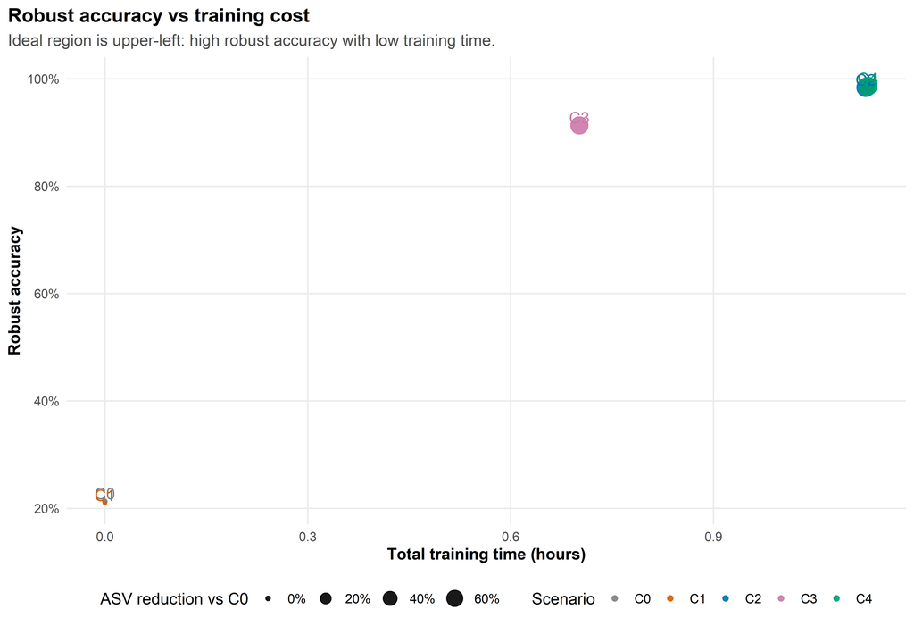

```r
p_robust_training <- efficiency_table |>
  ggplot(aes(x = total_training_hours, y = robust_accuracy, color = scenario_short, label = scenario_short)) +
  geom_point(aes(size = asv_reduction_vs_c0), alpha = 0.9) +
  geom_text(nudge_y = 0.015, show.legend = FALSE) +
  scale_color_manual(values = scenario_palette, drop = FALSE) +
  scale_y_continuous(labels = scales::percent_format(accuracy = 1)) +
  scale_size_continuous(labels = scales::percent_format(accuracy = 1)) +
  labs(
    title = "Robust accuracy vs training cost",
    subtitle = "Ideal region is upper-left: high robust accuracy with low training time.",
    x = "Total training time (hours)",
    y = "Robust accuracy",
    color = "Scenario",
    size = "ASV reduction vs C0"
  ) +
  base_theme()

print(p_robust_training)
```

```r
save_eff_figure(
  p_robust_training,
  "01_robust_accuracy_vs_training_cost.png",
  width = 9.5,
  height = 6.5
)
```

## 11.2 ASV reduction vs training cost

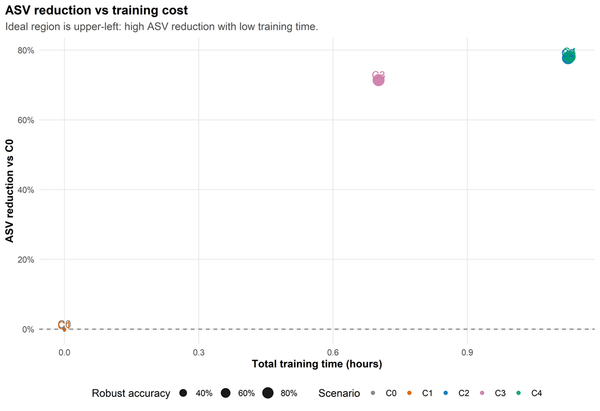

```r
p_asv_training <- efficiency_table |>
  ggplot(aes(x = total_training_hours, y = asv_reduction_vs_c0, color = scenario_short, label = scenario_short)) +
  geom_hline(yintercept = 0, linetype = "dashed", color = "grey45") +
  geom_point(aes(size = robust_accuracy), alpha = 0.9) +
  geom_text(nudge_y = 0.015, show.legend = FALSE) +
  scale_color_manual(values = scenario_palette, drop = FALSE) +
  scale_y_continuous(labels = scales::percent_format(accuracy = 1)) +
  scale_size_continuous(labels = scales::percent_format(accuracy = 1)) +
  labs(
    title = "ASV reduction vs training cost",
    subtitle = "Ideal region is upper-left: high ASV reduction with low training time.",
    x = "Total training time (hours)",
    y = "ASV reduction vs C0",
    color = "Scenario",
    size = "Robust accuracy"
  ) +
  base_theme()

print(p_asv_training)
```

```r
save_eff_figure(
  p_asv_training,
  "02_asv_reduction_vs_training_cost.png",
  width = 9.5,
  height = 6.5
)
```

## 11.3 Robust accuracy vs inference cost

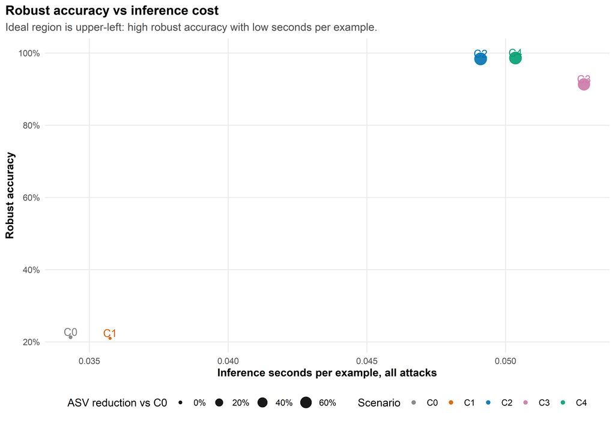

```r
p_robust_inference <- efficiency_table |>
  ggplot(aes(x = inference_seconds_per_example_all_attacks, y = robust_accuracy, color = scenario_short, label = scenario_short)) +
  geom_point(aes(size = asv_reduction_vs_c0), alpha = 0.9) +
  geom_text(nudge_y = 0.015, show.legend = FALSE) +
  scale_color_manual(values = scenario_palette, drop = FALSE) +
  scale_y_continuous(labels = scales::percent_format(accuracy = 1)) +
  scale_size_continuous(labels = scales::percent_format(accuracy = 1)) +
  labs(
    title = "Robust accuracy vs inference cost",
    subtitle = "Ideal region is upper-left: high robust accuracy with low seconds per example.",
    x = "Inference seconds per example, all attacks",
    y = "Robust accuracy",
    color = "Scenario",
    size = "ASV reduction vs C0"
  ) +
  base_theme()

print(p_robust_inference)
```

```r
save_eff_figure(
  p_robust_inference,
  "03_robust_accuracy_vs_inference_cost.png",
  width = 9.5,
  height = 6.5
)
```

## 11.4 ASV vs inference cost

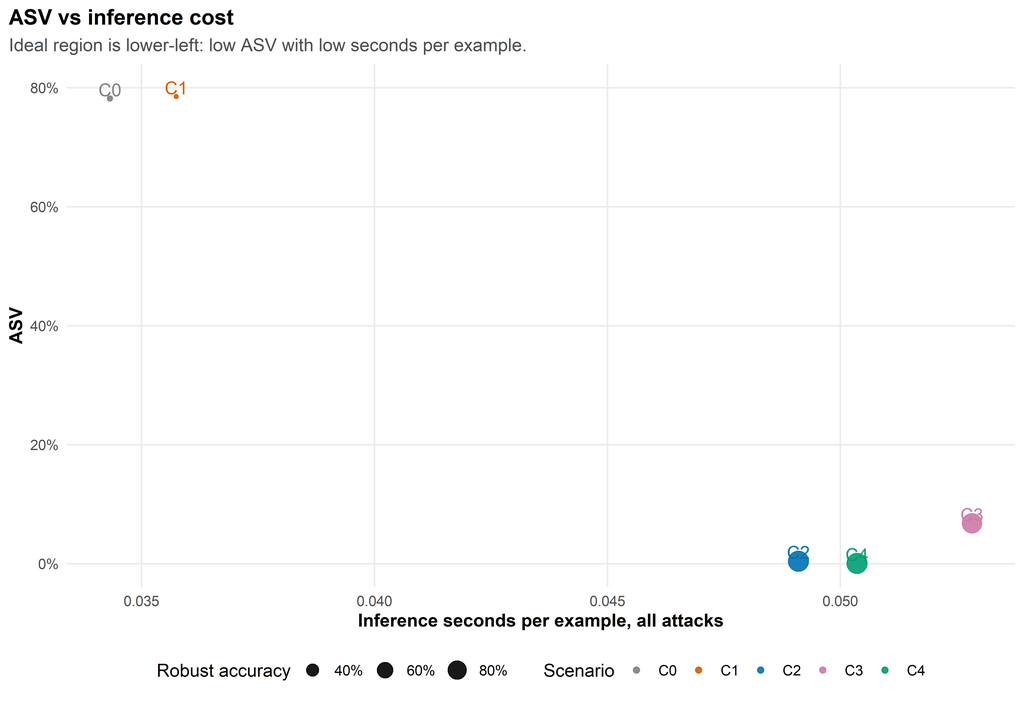

```r
p_asv_inference <- efficiency_table |>
  ggplot(aes(x = inference_seconds_per_example_all_attacks, y = asv_rate, color = scenario_short, label = scenario_short)) +
  geom_point(aes(size = robust_accuracy), alpha = 0.9) +
  geom_text(nudge_y = 0.015, show.legend = FALSE) +
  scale_color_manual(values = scenario_palette, drop = FALSE) +
  scale_y_continuous(labels = scales::percent_format(accuracy = 1)) +
  scale_size_continuous(labels = scales::percent_format(accuracy = 1)) +
  labs(
    title = "ASV vs inference cost",
    subtitle = "Ideal region is lower-left: low ASV with low seconds per example.",
    x = "Inference seconds per example, all attacks",
    y = "ASV",
    color = "Scenario",
    size = "Robust accuracy"
  ) +
  base_theme()

print(p_asv_inference)
```

```r
save_eff_figure(
  p_asv_inference,
  "04_asv_vs_inference_cost.png",
  width = 9.5,
  height = 6.5
)
```

## 11.5 Cost-benefit bars

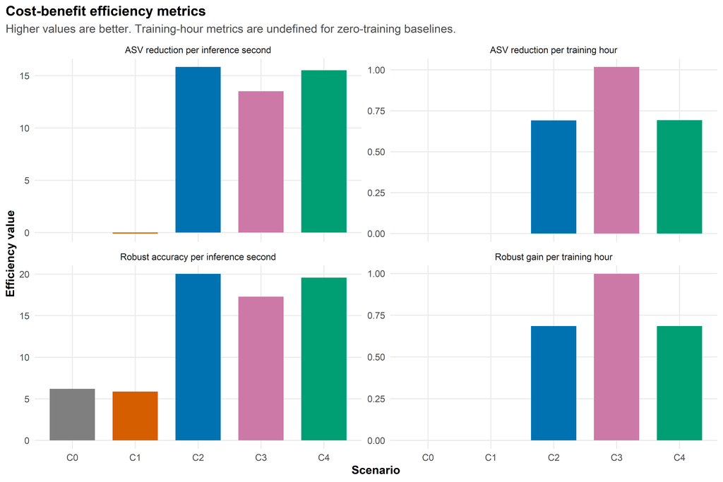

```r
efficiency_bar_data <- efficiency_table |>
  select(
    scenario_short,
    robust_gain_per_training_hour,
    asv_reduction_per_training_hour,
    robust_accuracy_per_second_per_example,
    asv_reduction_per_second_per_example
  ) |>
  pivot_longer(
    cols = -scenario_short,
    names_to = "efficiency_metric",
    values_to = "value"
  ) |>
  mutate(
    efficiency_metric = recode(
      efficiency_metric,
      robust_gain_per_training_hour = "Robust gain per training hour",
      asv_reduction_per_training_hour = "ASV reduction per training hour",
      robust_accuracy_per_second_per_example = "Robust accuracy per inference second",
      asv_reduction_per_second_per_example = "ASV reduction per inference second"
    )
  )

p_efficiency_bars <- efficiency_bar_data |>
  ggplot(aes(x = scenario_short, y = value, fill = scenario_short)) +
  geom_col(width = 0.72, show.legend = FALSE) +
  facet_wrap(~ efficiency_metric, scales = "free_y") +
  scale_fill_manual(values = scenario_palette, drop = FALSE) +
  labs(
    title = "Cost-benefit efficiency metrics",
    subtitle = "Higher values are better. Training-hour metrics are undefined for zero-training baselines.",
    x = "Scenario",
    y = "Efficiency value"
  ) +
  base_theme()

print(p_efficiency_bars)
```

```r
save_eff_figure(
  p_efficiency_bars,
  "05_cost_benefit_efficiency_bars.png",
  width = 10.5,
  height = 7
)
```

## 11.6 Balanced efficiency score

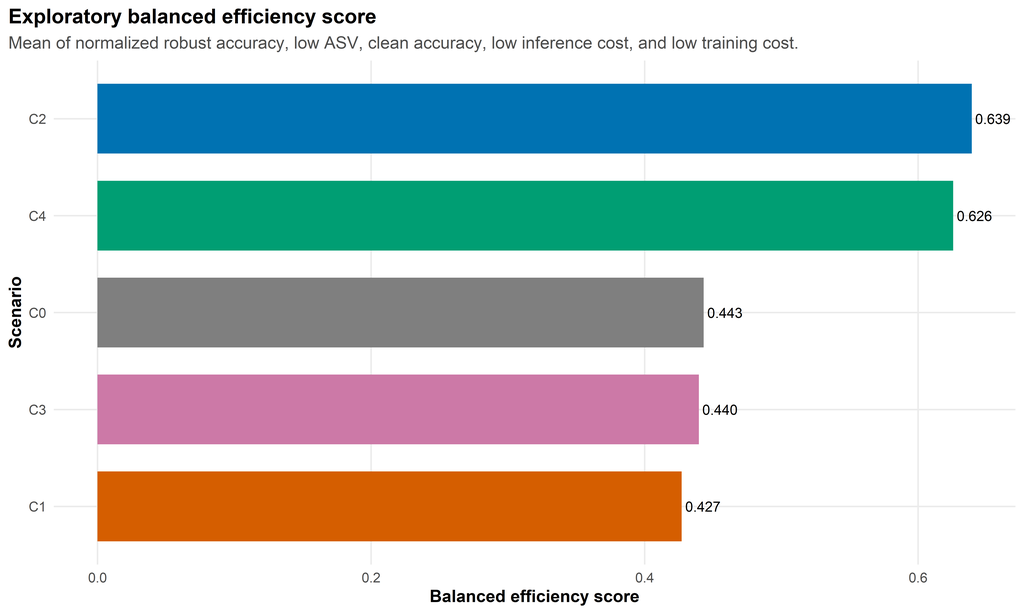

```r
p_balanced_score <- efficiency_table |>
  ggplot(aes(x = fct_reorder(scenario_short, balanced_efficiency_score), y = balanced_efficiency_score, fill = scenario_short)) +
  geom_col(width = 0.72, show.legend = FALSE) +
  geom_text(
    aes(label = scales::number(balanced_efficiency_score, accuracy = 0.001)),
    hjust = -0.1,
    size = 3.5
  ) +
  coord_flip() +
  scale_fill_manual(values = scenario_palette, drop = FALSE) +
  labs(
    title = "Exploratory balanced efficiency score",
    subtitle = "Mean of normalized robust accuracy, low ASV, clean accuracy, low inference cost, and low training cost.",
    x = "Scenario",
    y = "Balanced efficiency score"
  ) +
  base_theme()

print(p_balanced_score)
```

```r
save_eff_figure(
  p_balanced_score,
  "06_balanced_efficiency_score.png",
  width = 10,
  height = 6
)
```

## 11.7 Pareto-front summary

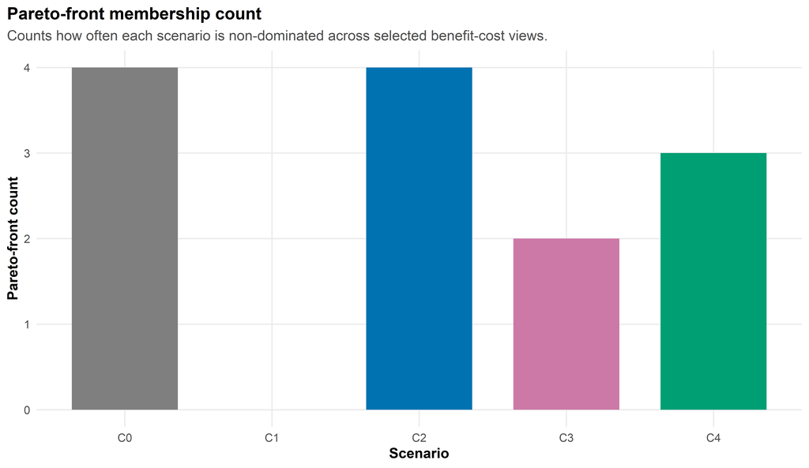

```r
p_pareto <- pareto_summary |>
  ggplot(aes(x = scenario_short, y = pareto_count, fill = scenario_short)) +
  geom_col(width = 0.72, show.legend = FALSE) +
  scale_fill_manual(values = scenario_palette, drop = FALSE) +
  scale_y_continuous(breaks = 0:4) +
  labs(
    title = "Pareto-front membership count",
    subtitle = "Counts how often each scenario is non-dominated across selected benefit-cost views.",
    x = "Scenario",
    y = "Pareto-front count"
  ) +
  base_theme()

print(p_pareto)
```

```r
save_eff_figure(
  p_pareto,
  "07_pareto_front_membership_count.png",
  width = 9.5,
  height = 5.5
)
```

## 11.8 Training, inference, and quality heatmap

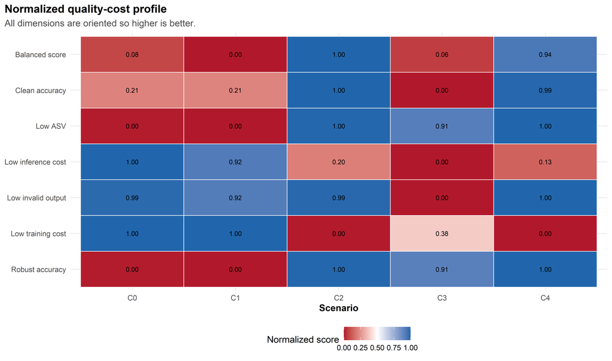

```r
heatmap_data <- efficiency_table |>
  select(
    scenario_short,
    clean_accuracy,
    robust_accuracy,
    asv_rate,
    invalid_output_rate_attacked,
    total_training_hours,
    inference_seconds_per_example_all_attacks,
    balanced_efficiency_score
  ) |>
  mutate(
    clean_accuracy = safe_minmax(clean_accuracy, higher_is_better = TRUE),
    robust_accuracy = safe_minmax(robust_accuracy, higher_is_better = TRUE),
    asv_rate = safe_minmax(asv_rate, higher_is_better = FALSE),
    invalid_output_rate_attacked = safe_minmax(invalid_output_rate_attacked, higher_is_better = FALSE),
    total_training_hours = safe_minmax(total_training_hours, higher_is_better = FALSE),
    inference_seconds_per_example_all_attacks = safe_minmax(inference_seconds_per_example_all_attacks, higher_is_better = FALSE),
    balanced_efficiency_score = safe_minmax(balanced_efficiency_score, higher_is_better = TRUE)
  ) |>
  pivot_longer(
    cols = -scenario_short,
    names_to = "dimension",
    values_to = "normalized_score"
  ) |>
  mutate(
    dimension = recode(
      dimension,
      clean_accuracy = "Clean accuracy",
      robust_accuracy = "Robust accuracy",
      asv_rate = "Low ASV",
      invalid_output_rate_attacked = "Low invalid output",
      total_training_hours = "Low training cost",
      inference_seconds_per_example_all_attacks = "Low inference cost",
      balanced_efficiency_score = "Balanced score"
    )
  )

p_heatmap <- heatmap_data |>
  ggplot(aes(x = scenario_short, y = fct_rev(factor(dimension)), fill = normalized_score)) +
  geom_tile(color = "white", linewidth = 0.35) +
  geom_text(aes(label = scales::number(normalized_score, accuracy = 0.01)), size = 3) +
  scale_fill_gradient2(
    low = "#B2182B",
    mid = "white",
    high = "#2166AC",
    midpoint = 0.5,
    limits = c(0, 1)
  ) +
  labs(
    title = "Normalized quality-cost profile",
    subtitle = "All dimensions are oriented so higher is better.",
    x = "Scenario",
    y = NULL,
    fill = "Normalized score"
  ) +
  base_theme()

print(p_heatmap)
```

```r
save_eff_figure(
  p_heatmap,
  "08_normalized_quality_cost_profile.png",
  width = 11,
  height = 6.5
)
```

# 12 Paper-ready table

```r
paper_efficiency_table <- efficiency_table |>
  select(
    scenario_short,
    training_method,
    clean_accuracy,
    robust_accuracy,
    robust_gain_vs_c0,
    asv_rate,
    asv_reduction_vs_c0,
    invalid_output_rate_attacked,
    total_training_hours,
    inference_seconds_per_example_all_attacks,
    robust_gain_per_training_hour,
    asv_reduction_per_training_hour,
    robust_accuracy_per_second_per_example,
    asv_reduction_per_second_per_example,
    balanced_efficiency_score,
    pareto_robust_vs_training,
    pareto_asv_reduction_vs_training,
    pareto_robust_vs_inference
  ) |>
  mutate(
    clean_accuracy = fmt_pct(clean_accuracy),
    robust_accuracy = fmt_pct(robust_accuracy),
    robust_gain_vs_c0 = fmt_pct(robust_gain_vs_c0),
    asv_rate = fmt_pct(asv_rate),
    asv_reduction_vs_c0 = fmt_pct(asv_reduction_vs_c0),
    invalid_output_rate_attacked = fmt_pct(invalid_output_rate_attacked),
    total_training_hours = fmt_number(total_training_hours),
    inference_seconds_per_example_all_attacks = fmt_number(inference_seconds_per_example_all_attacks, accuracy = 0.0001),
    robust_gain_per_training_hour = fmt_number(robust_gain_per_training_hour, accuracy = 0.0001),
    asv_reduction_per_training_hour = fmt_number(asv_reduction_per_training_hour, accuracy = 0.0001),
    robust_accuracy_per_second_per_example = fmt_number(robust_accuracy_per_second_per_example, accuracy = 0.001),
    asv_reduction_per_second_per_example = fmt_number(asv_reduction_per_second_per_example, accuracy = 0.001),
    balanced_efficiency_score = fmt_number(balanced_efficiency_score, accuracy = 0.001)
  )

write_eff_csv(paper_efficiency_table, "12_paper_ready_efficiency_tradeoff_table.csv")

paper_efficiency_table |>
  knitr::kable(
    caption = "Table 9 - Paper-ready efficiency trade-off table."
  )
```

Table 9 - Paper-ready efficiency trade-off table.

| scenario_short | training_method | clean_accuracy | robust_accuracy | robust_gain_vs_c0 | asv_rate | asv_reduction_vs_c0 | invalid_output_rate_attacked | total_training_hours | inference_seconds_per_example_all_attacks | robust_gain_per_training_hour | asv_reduction_per_training_hour | robust_accuracy_per_second_per_example | asv_reduction_per_second_per_example | balanced_efficiency_score | pareto_robust_vs_training | pareto_asv_reduction_vs_training | pareto_robust_vs_inference |
| --- | --- | --- | --- | --- | --- | --- | --- | --- | --- | --- | --- | --- | --- | --- | --- | --- | --- |
| C0 | none | 77.3% | 21.3% | 0.0% | 78.2% | 0.0% | 0.0% | 0.00 | 0.0343 | - | - | 6.202 | 0.000 | 0.443 | TRUE | TRUE | TRUE |
| C1 | none | 77.3% | 21.0% | -0.3% | 78.5% | -0.3% | 0.0% | 0.00 | 0.0357 | - | - | 5.868 | -0.093 | 0.427 | FALSE | FALSE | FALSE |
| C2 | sft | 85.7% | 98.4% | 77.1% | 0.4% | 77.8% | 0.0% | 1.13 | 0.0491 | 0.6850 | 0.6909 | 20.034 | 15.835 | 0.639 | TRUE | TRUE | TRUE |
| C3 | dpo | 75.1% | 91.3% | 70.0% | 6.8% | 71.4% | 0.5% | 0.70 | 0.0528 | 0.9979 | 1.0176 | 17.285 | 13.516 | 0.440 | TRUE | TRUE | FALSE |
| C4 | sft | 85.6% | 98.6% | 77.3% | 0.0% | 78.1% | 0.0% | 1.13 | 0.0504 | 0.6852 | 0.6925 | 19.580 | 15.517 | 0.626 | TRUE | TRUE | TRUE |

# 13 Interpretation notes

```r
cat("
## How to interpret this report

This analysis connects defense quality with experimental cost.

Training-hour efficiency is meaningful mainly for C2, C3, and C4, because those scenarios have actual training runs. C0 and C1 have zero training cost, so ratios per training hour are undefined. For C1, the relevant interpretation is whether a format-only defense gives improvement without training.

Inference-cost efficiency uses seconds per example as the normalized cost metric. It answers whether a scenario is expensive to run after training.

The balanced efficiency score is exploratory. It combines normalized dimensions into one number, but it should not replace the individual metrics. It is useful for ranking and visualization, while the final interpretation should still inspect robust accuracy, ASV, clean utility, and cost separately.

Pareto-front membership means that no other scenario is simultaneously at least as good in benefit and at least as cheap in cost, with one strict improvement.
")
```

## 13.1 How to interpret this report

This analysis connects defense quality with experimental cost.

Training-hour efficiency is meaningful mainly for C2, C3, and C4, because those scenarios have actual training runs. C0 and C1 have zero training cost, so ratios per training hour are undefined. For C1, the relevant interpretation is whether a format-only defense gives improvement without training.

Inference-cost efficiency uses seconds per example as the normalized cost metric. It answers whether a scenario is expensive to run after training.

The balanced efficiency score is exploratory. It combines normalized dimensions into one number, but it should not replace the individual metrics. It is useful for ranking and visualization, while the final interpretation should still inspect robust accuracy, ASV, clean utility, and cost separately.

Pareto-front membership means that no other scenario is simultaneously at least as good in benefit and at least as cheap in cost, with one strict improvement.

# 14 Generated files

Tables are saved in:

```
tables/efficiency_tradeoff_analysis/
```

Figures are saved in:

```
figures/efficiency_tradeoff_analysis/
```

Main files:

```
01_quality_metrics_by_scenario.csv
02_training_runs_for_efficiency.csv
03_training_cost_by_scenario.csv
04_inference_split_metadata_for_efficiency.csv
05_inference_cost_by_seed.csv
06_inference_cost_by_scenario_split.csv
07_optional_pipeline_cost_by_scenario.csv
08_efficiency_tradeoff_master_table.csv
09_training_efficiency_ranking.csv
10_inference_efficiency_ranking.csv
11_pareto_efficiency_summary.csv
12_paper_ready_efficiency_tradeoff_table.csv

01_robust_accuracy_vs_training_cost.png
02_asv_reduction_vs_training_cost.png
03_robust_accuracy_vs_inference_cost.png
04_asv_vs_inference_cost.png
05_cost_benefit_efficiency_bars.png
06_balanced_efficiency_score.png
07_pareto_front_membership_count.png
08_normalized_quality_cost_profile.png
```